# 1. Objective

## 11. Project Report

### **Executive Summary:**

Dear Stakeholders, We present a comprehensive analysis of direct marketing campaigns, conducted by your esteemed organization. This study aims to provide valuable insights into the effectiveness of your marketing strategies and, more importantly, identify ways to optimize your resources. Our examination is based on a dataset spanning from May 2008 to November 2010, comprising 41,188 examples and 20 variables.

### 1. **Introduction and Objective:**

The primary goal of this study, conducted by BankBoostX, is to assess and predict the outcomes of direct marketing campaigns undertaken by a Portuguese banking institution. Focused on understanding the factors influencing clients' decisions to subscribe to a term deposit, the study aims to empower the bank's marketing strategies. By leveraging insights from a dataset spanning May 2008 to November 2010, the bank seeks to optimize its marketing tactics for enhanced success. BankBoostX envisions becoming a key stakeholder in this project, benefiting from refined marketing strategies and improved resource allocation.

### 2. **Data Exploration:**

The initial data exploration involves loading the dataset, subsetting it for manageability, and conducting a comprehensive analysis. Various statistical and visualization techniques, such as correlation matrices and histograms, are employed. Key observations include age-related patterns, correlations between economic indicators, and the impact of contact duration on subscription decisions.

[figure not shown]

[figure not shown]

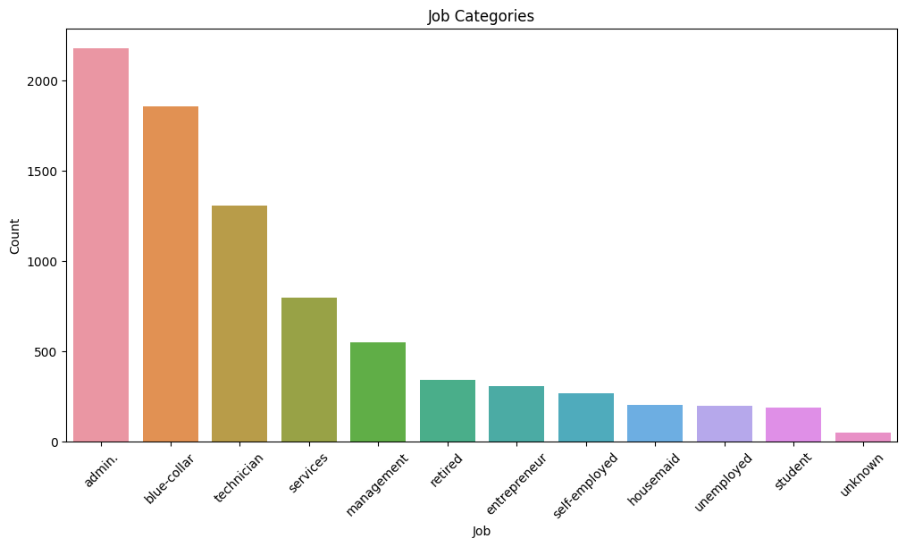

### 3. **Data Cleaning:**

Data cleaning is a crucial step, and in this case, columns with limited relevance, such as 'loan' and 'contact', are removed to streamline the dataset and enhance its focus on key features.

### 4. **Adaptation and Categorization:**

To provide more meaningful insights, the study introduces new categories such as 'Age Groups' and 'Contact Duration Categories', enabling a deeper analysis of age and contact duration distributions. Additionally, a binary representation of the target variable 'y' is introduced for ease of interpretation.

### 5. **Descriptive Visualization:**

Several descriptive visualizations, including bar charts, heatmaps, and kernel density plots, are employed to understand the distribution of data across various dimensions. These visualizations offer insights into education-based subscription patterns, contact duration dynamics, age distributions, and the temporal evolution of subscriptions.

### 6. **Cluster Analysis:**

Two approaches to cluster analysis are explored. Hierarchical clustering is applied both manually and using external libraries, revealing distinctive clusters and their characteristics. K-means clustering, facilitated by both a custom implementation and scikit-learn's KMeans, further refines the grouping of data points.

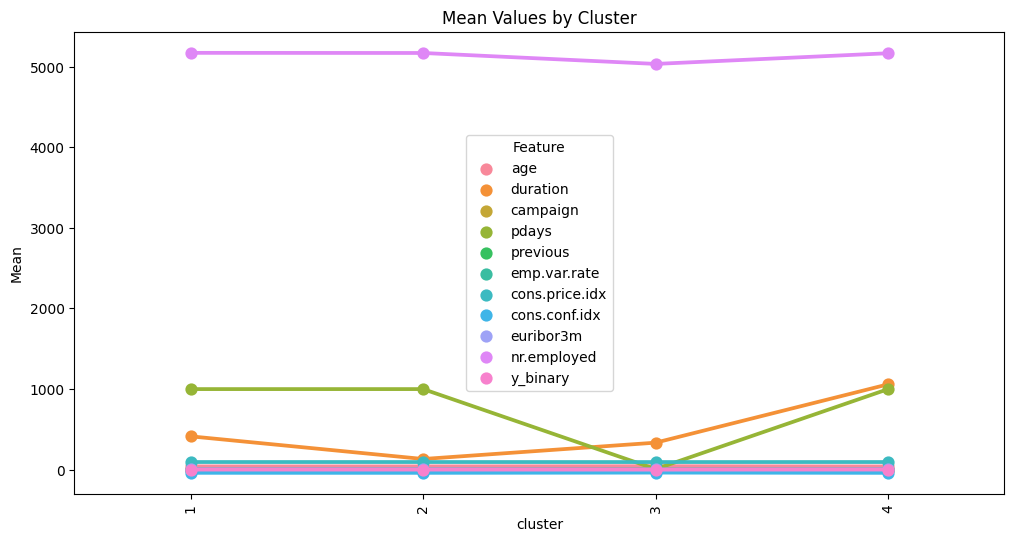

### 7. **Dendrogram:**

The dendrogram provides a visual representation of hierarchical clustering, revealing the optimal number of clusters based on the observable distances. The clustering analysis is refined, and four distinct clusters are identified as optimal for this dataset.

### 8. **Cluster Analysis Insights:**

Detailed insights into each cluster's characteristics are presented, emphasizing the variations in features such as age, contact duration, and previous contacts. Visualizations highlight the mean distribution of these features across clusters, providing a nuanced understanding of their impact on subscription decisions.

### 9. **Step-by-step K-means and sklearn.cluster:**

Both manual and scikit-learn implementations of K-means clustering are employed, showcasing how data points are assigned to clusters based on features like 'pdays', 'duration', and 'y_binary'. Visualizations underscore the distinctiveness of each cluster and the effectiveness of K-means in grouping similar data points.

In conclusion, the comprehensive study conducted by BankBoostX provides valuable insights into the intricacies of direct marketing campaigns in the banking sector. The combination of exploratory data analysis, clustering techniques, and predictive modeling contributes to a holistic understanding of customer behavior and informs strategic decision-making for the bank's marketing endeavors.